# Network Analytics (2623) — Group Assignment 2 - Group 12

# INSTRUCTIONS

- This is a group assignment.
- Submit your answer digitally as two files through Moodle:
  - An R markdown file (extension **Rmd**). Use the template provided to you and provide your answers (both code and text) below each question.
  - An **HTML** file “knitted” by RStudio including all the results and plots. More details on how to create these files will be provided in class on week 3.
- Follow the Style Guide (available on Moodle). You can be penalized on up to 20% in each question for which you do not follow the Style Guide.
- Questions regarding the assignment should be posted exclusively on the respective discussion forum on Moodle.
- **Deadline:** Sunday, 3 May 2026, 23:59 (Lisbon time)

**Warning:** The detection of any form of plagiarism in your work means the assignment will be graded with ZERO points.

# Movie Networks

We are interested in assessing what are the most important movies in the decade 2010-2019. We will use different strategies to do so. First, we will load and prepare the data.

## Load and prepare the data

The first step is to load and prepare the movie data. The following instructions perform some routine data preparation operations. Each set of instructions is preceded by a comment explaining the procedure. Run the code below and try to understand each line of code as you might need to perform some changes.

```r
library(data.table)     # Run once per session
library(ggplot2)        # Run once per session

# Load data from file 20200120-imdb_movie_actor.csv (do not forget to
# change your working directory to the folder containing the
# 20200120-imdb_movie_actor.csv file)
dt.movie.actor <- fread("20200120-imdb_movie_actor.csv")

# Count in how many movies each actor has participated and how many
# principal actor each movie has
dt.movie.actor[, n_movies := .N, by = actor]
dt.movie.actor[, n_actors := .N, by = list(movie, year)]

# Remove entries in which actors have no name
dt.movie.actor <- dt.movie.actor[!(actor == "")]

# Save dt.movie.actor. Next time you can simply call the load function (below)
save(dt.movie.actor, file = "imdb_movie_actor.RData")
```

Load the data that you prepared using the instructions below. As mentioned in the comments, you can start from this line if you have previously saved these data.

```r
# Load previously saved dt.movie.actor. You can
# start in this line if you have previously saved these data.
load("imdb_movie_actor.RData")
```

## Questions (`data.table`) `[7 points]`

This set of questions require that you know how to manipulate a `data.table`. Answer each of the following questions below. Include all the code you created/used in your answer.

1. What is the total amount of movies in the `dt.movie.actor` dataset? `[1 point]`

```r
# Count the number of distinct movie titles across the entire dataset
n.movies <- dt.movie.actor[, uniqueN(movie)]

print(paste("Number of unique movies:", n.movies))
```

```
## [1] "Number of unique movies: 368522"
```

2. List the actors from the movie `"Fight Club (1999)"`. List the actors from the movie `"Se7en (1995)"`. `[1 point]`

```r
# Filter rows where the movie is "Fight Club (1999)"
# and extract unique actor names
actors.fight.club <- dt.movie.actor[
    movie == "Fight Club (1999)",
    unique(actor)
]
print(
    paste("Actors in Fight Club (1999):",
    paste(actors.fight.club, collapse = ", "))
)
```

```
## [1] "Actors in Fight Club (1999): Brad Pitt (b.1963), Meat Loaf (b.1947), Edward Norton (b.1969), Zach Grenier (b.1954)"
```

```r
# Filter rows where the movie is "Se7en (1995)"
# and extract unique actor names
actors.se7en <- dt.movie.actor[
    movie == "Se7en (1995)",
    unique(actor)
]
print(
    paste("Actors in Se7en (1995):",
    paste(actors.se7en, collapse = ", "))
)
```

```
## [1] "Actors in Se7en (1995): Brad Pitt (b.1963), Morgan Freeman (b.1937), Kevin Spacey (b.1959), Andrew Kevin Walker (b.1964)"
```

3. Which actors participated on both movies? Hint: The function `intersect` calculates the intersection of two sets. `[1 point]`

```r
# Find actors that appear in both vectors
# (set intersection of the two actor lists)
actors.both.movies <- intersect(actors.fight.club, actors.se7en)
print(
    paste("Actor(s) in both movies:",
    paste(actors.both.movies, collapse = ", "))
)
```

```
## [1] "Actor(s) in both movies: Brad Pitt (b.1963)"
```

4. In which movies did Brad Pitt (b.1963) and George Clooney (b.1961) star together? `[1 point]`

```r
# Filter rows for Brad Pitt
# and retrieve the unique movie titles he appeared in
movies.brad.pitt <- dt.movie.actor[
    actor == "Brad Pitt (b.1963)",
    unique(movie)
]
# Filter rows for George Clooney
# and retrieve the unique movie titles he appeared in
movies.george.clooney <- dt.movie.actor[
    actor == "George Clooney (b.1961)",
    unique(movie)
]
# Find movies that both actors appeared in
# (set intersection of the two movie lists)
movies.both <- intersect(movies.brad.pitt, movies.george.clooney)
print(
    paste("Movie(s) with Brad Pitt and George Clooney:",
    paste(movies.both, collapse = ", "))
)
```

```
## [1] "Movie(s) with Brad Pitt and George Clooney: Ocean's Eleven (2001), Ocean's Twelve (2004), Ocean's Thirteen (2007), Burn After Reading (2008)"
```

5. Create a table that shows the number of movies released per year. This table should include three columns: `year`, `n_movies`, and `csum_n_movies`. The first column should contain the year, the second the number of movies in that year, and the third, the number of movies released since the first year in the data and up to the year in that line. Tip: Use the function `cumsum` and check if the amount in the last year is the same as the total number of movies in question 1. `[1 point]`

```r
# Count the number of unique movies released in each year
dt.movies.per.year <- dt.movie.actor[
  ,
  list(n_movies = uniqueN(movie)),
  by = year
]

# Sort the table in ascending chronological order
dt.movies.per.year <- dt.movies.per.year[order(year)]
# Add a cumulative sum column tracking the total movies
# released up to and including each year
dt.movies.per.year[, csum_n_movies := cumsum(n_movies)]

# Verify the final cumulative total equals
# the overall movie count computed in Q1
v.same.total <- dt.movies.per.year[.N, csum_n_movies] == n.movies

print("Number of movies per year:")
```

```
## [1] "Number of movies per year:"
```

```r
print(dt.movies.per.year)
```

```
##       year n_movies csum_n_movies
##      <int>    <int>         <int>
##   1:  1894        1             1
##   2:  1899        1             2
##   3:  1900        1             3
##   4:  1905        2             5
##   5:  1906        4             9
##  ---
## 114:  2015    10731        322844
## 115:  2016    11409        334253
## 116:  2017    11667        345920
## 117:  2018    11775        357695
## 118:  2019    10827        368522
```

```r
print(
    paste("Is the cumulative sum equal to the total number of movies?",
    v.same.total)
)
```

```
## [1] "Is the cumulative sum equal to the total number of movies? TRUE"
```

6. Which actor/actress has starred in the most movies across all data? After (and including) 2000, which year has the most movie participations by a single actor/actress? Who is that actor/actress? What do these two actors/actresses have in common? `[1 point]`

```r
# Extract one row per actor retaining the precomputed
# total movie count (n_movies)
dt.actor.total <- unique(dt.movie.actor[, list(actor, n_movies)])

# Keep only the actor(s) with the highest overall movie count
# sorted alphabetically
dt.actor.most.all <- dt.actor.total[
  n_movies == max(n_movies)
][order(actor)]

# Count each actor's participations per year
# restricted to 2000 and later
dt.actor.year.2000 <- dt.movie.actor[
  year >= 2000,
  list(n_participations = .N),
  by = list(year, actor)
]

# Filter to the year-actor pair(s) with the single highest participation count
# sorted by year then actor
dt.actor.most.year.2000 <- dt.actor.year.2000[
  n_participations == max(n_participations)
][order(year, actor)]

print("Actor who starred in the most movies overall:")
```

```
## [1] "Actor who starred in the most movies overall:"
```

```r
print(dt.actor.most.all)
```

```
##                    actor n_movies
##                   <char>    <int>
## 1: Brahmanandam (b.1956)      804
```

```r
print("Actor who starred in the most movies after (and including) 2000:")
```

```
## [1] "Actor who starred in the most movies after (and including) 2000:"
```

```r
print(dt.actor.most.year.2000)
```

```
##     year        actor n_participations
##    <int>       <char>            <int>
## 1:  2001 Anil Nagrath               35
```

7. Consider only the 10% most popular movies (by votes) in the decade 2010-2019. List the top 10 actors that starred in the most movies in the decade. Which year(s) has/have the most movie participations by a single actor? Hint: you can use the function `quantile` to find how many votes does the movie in percentile 90 have. `[1 point]`

```r
# Restrict the full dataset to movies released within the 2010-2019 decade
dt.decade <- dt.movie.actor[year >= 2010 & year <= 2019]

# Get one row per movie retaining year
# and vote count (removes per-actor duplicates)
dt.movies.decade <- unique(dt.decade[, list(movie, year, votes)])

# Compute the 90th percentile vote threshold
# i.e. the cutoff for the top 10% most voted movies
n.votes.p90 <- quantile(
  dt.movies.decade[, votes],
  probs = 0.90,
  na.rm = TRUE
)

# Keep only movies at or above the 90th percentile vote count
dt.popular.movies <- dt.movies.decade[votes >= n.votes.p90]

# Inner-join the decade actor rows with the popular movies list
# keeping only matching rows
dt.decade.popular <- dt.decade[
  dt.popular.movies,
  on = list(movie, year, votes),
  nomatch = 0
]

# Count distinct popular movies per actor
# then sort by most movies descending, then alphabetically
dt.top.actors.decade <- dt.decade.popular[
  ,
  list(n_movies = uniqueN(movie)),
  by = actor
][order(-n_movies, actor)]

# Trim the ranked list to the top 10 actors only
dt.top.actors.decade <- head(dt.top.actors.decade, 10)

# Count each actor's total appearances per year within the popular movies subset
dt.actor.year.decade <- dt.decade.popular[
  ,
  list(n_participations = .N),
  by = list(year, actor)
]

# Filter to the year-actor pair(s) with the
# highest single-year participation count
dt.actor.peak.year.decade <- dt.actor.year.decade[
  n_participations == max(n_participations)
][order(year, actor)]

print("Top 10 actors with the most popular movies (2010-2019):")
```

```
## [1] "Top 10 actors with the most popular movies (2010-2019):"
```

```r
print(dt.top.actors.decade)
```

```
##                           actor n_movies
##                          <char>    <int>
##  1:       Akshay Kumar (b.1967)       36
##  2:       Nicolas Cage (b.1964)       33
##  3:       James Franco (b.1978)       26
##  4:       Bruce Willis (b.1955)       24
##  5:     Robert De Niro (b.1943)       24
##  6:      Anna Kendrick (b.1985)       23
##  7:        John Cusack (b.1966)       23
##  8:  Samuel L. Jackson (b.1948)       23
##  9: Chloë Grace Moretz (b.1997)       22
## 10:     Dwayne Johnson (b.1972)       22
```

```r
print("Year and actor with the most participations:")
```

```
## [1] "Year and actor with the most participations:"
```

```r
print(dt.actor.peak.year.decade)
```

```
##     year                actor n_participations
##    <int>               <char>            <int>
## 1:  2014 Liam Neeson (b.1952)                7
```

## Questions (`ggplot2`) `[3 points]`

1. Plot a histogram with the number of movies per year. Which patterns do you observe? Is there anything strange? `[1 point]`

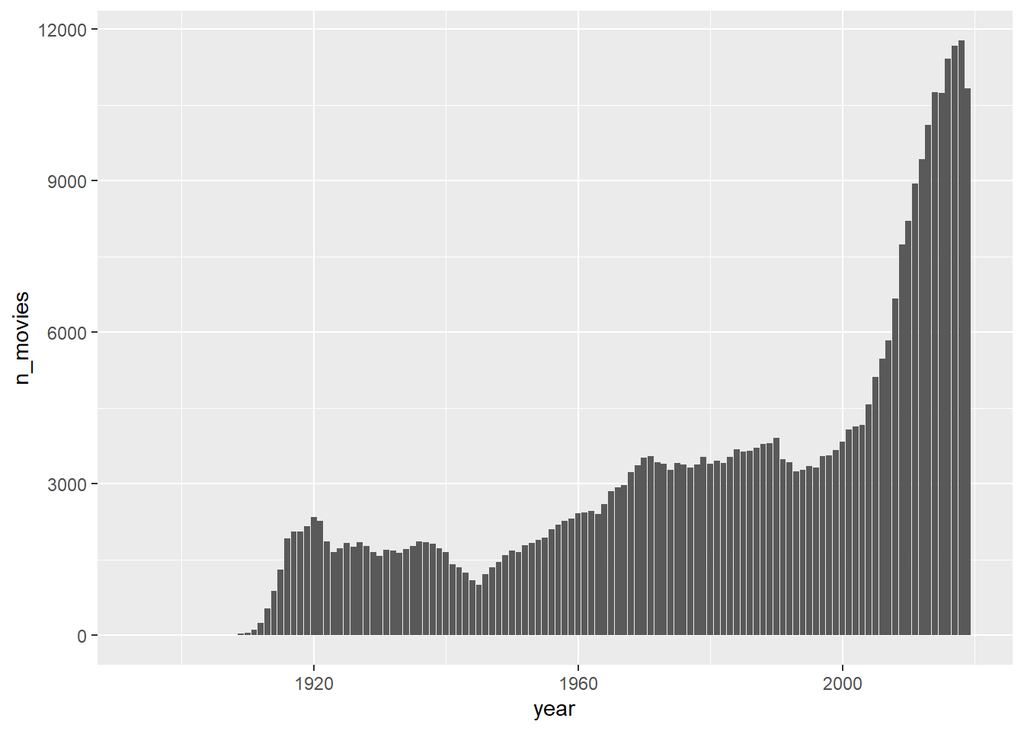

```r
dt.movies.per.year <- dt.movie.actor[, .(n_movies = uniqueN(movie)), by = year]

ggplot(dt.movies.per.year, aes(x = year, y = n_movies)) +
  geom_bar(stat = "identity")
```

2. Plot a histogram that represents the distribution of number of IMDb votes per movie. The x-axis should represent the number of votes and the y-axis should represent how many movies have x number of votes. Which patterns do you observe? `[1 point]`

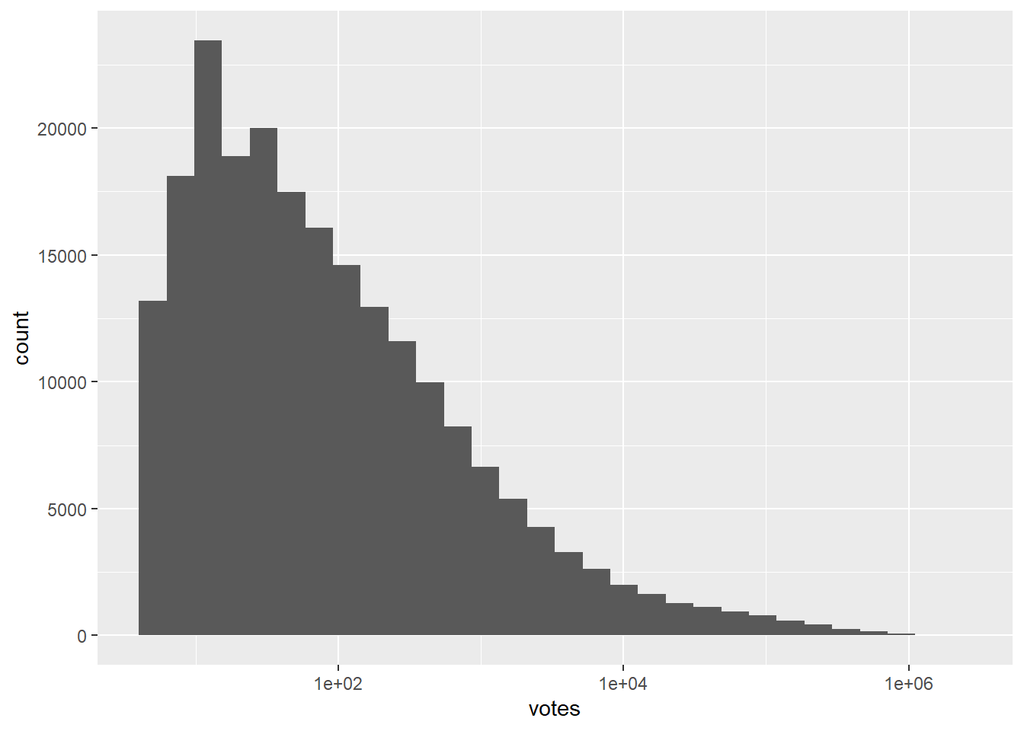

```r
dt.votes <- unique(dt.movie.actor[votes > 0, .(movie, votes)])

ggplot(dt.votes, aes(x = votes)) +
  geom_histogram() +
  scale_x_log10()
```

The distribution of IMDb votes per movie is extremely right-skewed. The vast majority of movies in the dataset have received very few votes while a tiny fraction of well-known blockbusters have accumulated hundreds of thousands or even millions of votes. This makes intuitive sense, as most movies in the dataset are obscure or low-budget productions that very few people have watched or rated. The log scale makes the shape much clearer, revealing that the distribution peaks before 100 votes and then tapers off gradually towards the right.

3. Plot a histogram that represents the distribution of the number of actors per movie. The x-axis should represent the number of actors and the y-axis should represent how many movies have x number of actors. Describe your findings. `[1 point]`

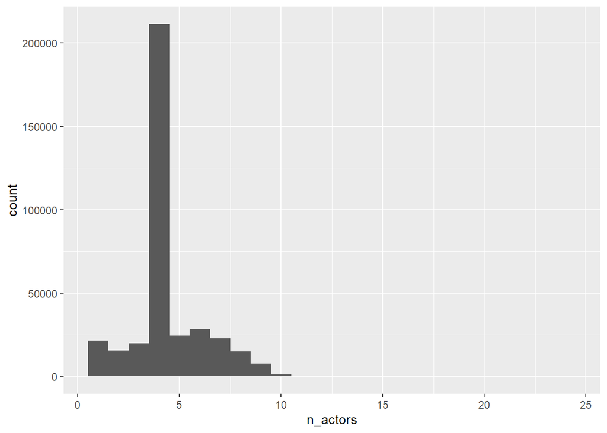

```r
dt.actors.per.movie <- unique(dt.movie.actor[, .(movie, n_actors)])

ggplot(dt.actors.per.movie, aes(x = n_actors)) +
  geom_histogram(binwidth = 1)
```

## Questions (`igraph`) `[10 points]`

1. From this question onwards, and until the end of the assignment, focus only on the actors that participated on the top 50 most popular movies from the 2010-2019 decade (by number of votes). Load the `igraph` package and create a bipartite graph in which the edges correspond to actors’ participation in movies. How many movie participations exist? `[1 point]`

```r
library(igraph)

# Actors that participated on the top 50 most popular movies from the 2010-2019 decade
top.movies.2010.2019 <- dt.movie.actor[year >= 2010 & year <= 2019,
                                       .N, by = list(movie, votes)][order(-votes)][1:50, movie]

actors.in.top <- dt.movie.actor[movie %in% top.movies.2010.2019, unique(actor)]

# Build graph
edges <- dt.movie.actor[movie %in% top.movies.2010.2019, list(actor, movie)]

g.bipartite <- graph_from_data_frame(edges, directed = FALSE)

V(g.bipartite)$type <- !V(g.bipartite)$name %in% unique(edges$movie)


# Summary and number of participations
summary(g.bipartite)
```

```
## IGRAPH 0293cc5 UN-B 194 200 --
## + attr: name (v/c), type (v/l)
```

```r
ecount(g.bipartite)
```

```
## [1] 200
```

There are 200 movie participations.

2. Create a graph in which two movies are connected to each other if they have at least one actor in common. Calculate the degree centrality for each of the movies, and remove movies with no connections to other movies. Hint: the function `induced.subgraph` allows the creation of graphs with only a subset of the vertices. Calculate the following additional centrality measures for each of these movies: `[2 points]`
   - Closeness centrality
   - Betweenness centrality
   - Eigenvector centrality

```r
# Create list with type attribute
all.actors <- dt.movie.actor[movie %in% top.movies.2010.2019,
                             list(name = unique(actor), type = TRUE)]
all.movies <- dt.movie.actor[movie %in% top.movies.2010.2019,
                             list(name = unique(movie), type = FALSE)]
all.vertices <- rbind(all.actors, all.movies)

# Build graph
g <- graph_from_data_frame(dt.movie.actor[movie %in% top.movies.2010.2019,
                                     list(movie, actor)], directed = FALSE, vertices = all.vertices)

g.movies <- bipartite_projection(g)$proj1

summary(g.movies)
```

```
## IGRAPH 02a0202 UNW- 50 80 --
## + attr: name (v/c), weight (e/n)
```

```r
# Calculate degree centrality
V(g.movies)$degree <- degree(g.movies)

# Remove movies with no connections
g.movies.connected <- induced_subgraph(g.movies,
                                       vids = V(g.movies)[V(g.movies)$degree > 0])
summary(g.movies.connected)
```

```
## IGRAPH 02a25bf UNW- 38 80 --
## + attr: name (v/c), degree (v/n), weight (e/n)
```

```r
# Calculate all centrality measures
V(g.movies.connected)$degree        <- degree(g.movies.connected)
V(g.movies.connected)$closeness     <- closeness(g.movies.connected)
V(g.movies.connected)$betweenness   <- betweenness(g.movies.connected)
V(g.movies.connected)$evcent        <- eigen_centrality(g.movies.connected)$vector

dt.g.movies <- data.table(as_data_frame(g.movies.connected, "vertices"))
head(dt.g.movies[order(-betweenness)], 10)
```

```
##                                          name degree  closeness betweenness
##                                        <char>  <num>      <num>       <num>
##  1:                     Shutter Island (2010)      8 0.02040816   144.42857
##  2:                     Now You See Me (2013)      6 0.01851852    84.42857
##  3:                       The Revenant (2015)      7 0.01612903    63.50000
##  4: Batman v Superman: Dawn of Justice (2016)      4 0.01369863    47.00000
##  5:            Avengers: Age of Ultron (2015)     11 0.01923077    45.51667
##  6:             Avengers: Infinity War (2018)     11 0.01923077    45.51667
##  7:                  Avengers: Endgame (2019)     11 0.01923077    45.51667
##  8:            The Wolf of Wall Street (2013)      5 0.01587302    40.00000
##  9:                 X-Men: First Class (2011)      5 0.05555556    38.50000
## 10:         X-Men: Days of Future Past (2014)      4 0.04545455    27.00000
##           evcent
##            <num>
##  1: 2.449395e-01
##  2: 2.412304e-01
##  3: 2.351178e-02
##  4: 1.965956e-02
##  5: 1.000000e+00
##  6: 1.000000e+00
##  7: 1.000000e+00
##  8: 2.325598e-02
##  9: 6.322597e-17
## 10: 3.161299e-17
```

3. For each centrality measure, list the top 20 movies with highest centrality. How do you interpret the outcomes? In addition, report the exact betweenness centrality score of the **top-ranked movie by betweenness** to four decimal places. `[2 points]`

```r
# Top 20 by each measure
head(dt.g.movies[order(-degree)], 20)
```

```
##                                           name degree  closeness betweenness
##                                         <char>  <num>      <num>       <num>
##  1:             Avengers: Age of Ultron (2015)     11 0.01923077  45.5166667
##  2:              Avengers: Infinity War (2018)     11 0.01923077  45.5166667
##  3:                   Avengers: Endgame (2019)     11 0.01923077  45.5166667
##  4:                      Shutter Island (2010)      8 0.02040816 144.4285714
##  5:                        The Avengers (2012)      8 0.01149425   0.6000000
##  6:          Captain America: Civil War (2016)      8 0.01149425   0.6000000
##  7:                        The Revenant (2015)      7 0.01612903  63.5000000
##  8:  Captain America: The First Avenger (2011)      6 0.01470588  10.7619048
##  9: Captain America: The Winter Soldier (2014)      6 0.01428571   0.4285714
## 10:                          Iron Man 2 (2010)      6 0.01470588  10.7619048
## 11:                          Iron Man 3 (2013)      6 0.01470588  10.7619048
## 12:                      Now You See Me (2013)      6 0.01851852  84.4285714
## 13:                  X-Men: First Class (2011)      5 0.05555556  38.5000000
```

[output cut: 33 more lines]

```r
head(dt.g.movies[order(-closeness)], 20)
```

```
##                                           name degree  closeness betweenness
##                                         <char>  <num>      <num>       <num>
##  1:                  X-Men: First Class (2011)      5 0.05555556    38.50000
##  2:             Silver Linings Playbook (2012)      5 0.04545455    19.50000
##  3:          X-Men: Days of Future Past (2014)      4 0.04545455    27.00000
##  4:     The Hunger Games: Catching Fire (2013)      3 0.04000000     0.00000
##  5:                    The Hunger Games (2012)      3 0.04000000     0.00000
##  6:                    12 Years a Slave (2013)      2 0.03846154    10.00000
##  7:                               Joker (2019)      1 0.03125000     0.00000
##  8:             Guardians of the Galaxy (2014)      1 0.03125000     0.00000
##  9:   The Hobbit: An Unexpected Journey (2012)      2 0.03125000     0.00000
## 10: The Hobbit: The Desolation of Smaug (2013)      2 0.03125000     0.00000
## 11:                         World War Z (2013)      1 0.02777778     0.00000
## 12:                               Logan (2017)      1 0.02380952     0.00000
## 13:                      Shutter Island (2010)      8 0.02040816   144.42857
```

[output cut: 33 more lines]

```r
head(dt.g.movies[order(-betweenness)], 20)
```

```
##                                          name degree  closeness betweenness
##                                        <char>  <num>      <num>       <num>
##  1:                     Shutter Island (2010)      8 0.02040816   144.42857
##  2:                     Now You See Me (2013)      6 0.01851852    84.42857
##  3:                       The Revenant (2015)      7 0.01612903    63.50000
##  4: Batman v Superman: Dawn of Justice (2016)      4 0.01369863    47.00000
##  5:            Avengers: Age of Ultron (2015)     11 0.01923077    45.51667
##  6:             Avengers: Infinity War (2018)     11 0.01923077    45.51667
##  7:                  Avengers: Endgame (2019)     11 0.01923077    45.51667
##  8:            The Wolf of Wall Street (2013)      5 0.01587302    40.00000
##  9:                 X-Men: First Class (2011)      5 0.05555556    38.50000
## 10:         X-Men: Days of Future Past (2014)      4 0.04545455    27.00000
## 11:                       Interstellar (2014)      3 0.01219512    24.50000
## 12:                               Thor (2011)      4 0.01428571    24.42857
## 13:            Silver Linings Playbook (2012)      5 0.04545455    19.50000
```

[output cut: 33 more lines]

```r
head(dt.g.movies[order(-evcent)], 20)
```

```
##                                           name degree   closeness betweenness
##                                         <char>  <num>       <num>       <num>
##  1:                   Avengers: Endgame (2019)     11 0.019230769  45.5166667
##  2:              Avengers: Infinity War (2018)     11 0.019230769  45.5166667
##  3:             Avengers: Age of Ultron (2015)     11 0.019230769  45.5166667
##  4:                        The Avengers (2012)      8 0.011494253   0.6000000
##  5:          Captain America: Civil War (2016)      8 0.011494253   0.6000000
##  6: Captain America: The Winter Soldier (2014)      6 0.014285714   0.4285714
##  7:                          Iron Man 3 (2013)      6 0.014705882  10.7619048
##  8:                          Iron Man 2 (2010)      6 0.014705882  10.7619048
##  9:  Captain America: The First Avenger (2011)      6 0.014705882  10.7619048
## 10:                      Shutter Island (2010)      8 0.020408163 144.4285714
## 11:                      Now You See Me (2013)      6 0.018518519  84.4285714
## 12:                                Thor (2011)      4 0.014285714  24.4285714
## 13:                        The Revenant (2015)      7 0.016129032  63.5000000
```

[output cut: 33 more lines]

```r
# Betweenness of top-ranked movie
dt.g.movies[order(-betweenness)][1, .(name, betweenness = round(betweenness, 4))]
```

```
##                     name betweenness
##                   <char>       <num>
## 1: Shutter Island (2010)    144.4286
```

Interpretation of Centrality Measures: Degree Centrality: The Avengers series dominates with the highest degree of centrality, with each film having 11 connections. This indicates that these films share the most actors with other movies in the top 50, making them highly connected hubs in the actor-sharing network. Closeness Centrality: X-Men: First Class (2011) has the highest closeness centrality score (0.0556), followed by other films with large casts, such as Silver Linings Playbook (2012) and X-Men: Days of Future Past (2014). On average, these movies are closer to the other movies, suggesting that they occupy more central positions in the network’s overall structure. Betweenness Centrality: Shutter Island (2010) takes the top spot with a score of 144.4286, followed by Now You See Me (2013) with 84.4286 and The Revenant (2015) with 63.50. These films act as crucial bridges, connecting different clusters of films through shared actors. Shutter Island is especially important in connecting parts of the network that would otherwise be disconnected. Eigenvector Centrality: The three Avengers films received perfect scores of 1.0, indicating that they are connected to other highly connected movies. Captain America: Civil War (2016) and The Avengers (2012) also received high scores (0.78), demonstrating their connection to significant nodes in the network.

Key Insight: Different films are central for different reasons. The Avengers films are highly connected and influential, while Shutter Island acts as a critical bridge between different movie clusters. Films with high closeness centrality, such as X-Men: First Class, occupy more balanced positions within the network.

The exact betweenness centrality of the top-ranked movie is: Shutter Island (2010): 144.4286

4. Calculate the average clustering coefficient for the movies network. *Hint: use `transitivity(g, type = "global")` to calculate the average clustering coefficient. For movie co-occurrence networks of this type, values typically fall in the range 0.75–0.85.* `[1 point]`

```r
avg.clustering <- transitivity(g.movies.connected, type = "global")

print(paste("Average clustering coefficient:", round(avg.clustering, 4)))
```

```
## [1] "Average clustering coefficient: 0.6327"
```

The average clustering coefficient for the movies network is 0.6327. This value indicates a high degree of connectivity among movies through shared actors. However, it is slightly lower than the typical range of 0.75-0.85 usually observed in such networks. This deviation might be due to the specific selection criteria, as focusing only on the top 50 most popular movies limits the presence of smaller, tightly knit clusters that might be found in a broader dataset.

5. Choose one movie you like and plot the movie, their direct neighbors and the links among them. What is the clustering coefficient of this movie? Which is the actor with most participations among these (neighbor) movies, but not having participated in the movie itself? *Note: in your written answer, explicitly state the ratio of your chosen movie’s clustering coefficient to the network average you computed in Question 4 (i.e. report both numbers and their ratio to two decimal places).* `[2 points]`

```r
# Define the target movie
my.movie <- "The Avengers (2012)"
print(paste("Selected Movie:", my.movie))
```

```
## [1] "Selected Movie: The Avengers (2012)"
```

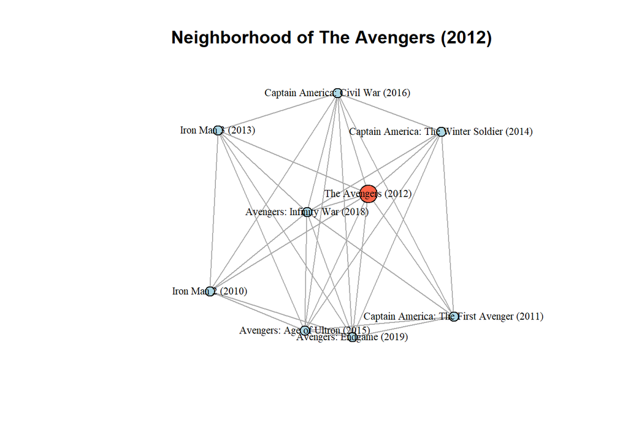

```r
# Extract the ego graph (neighborhood) for the selected movie
g.movie.neighborhood <- make_ego_graph(
  g.movies.connected,
  order = 1,
  nodes = my.movie
)[[1]]

# Plot the neighborhood network
plot(
  g.movie.neighborhood,
  vertex.size = ifelse(V(g.movie.neighborhood)$name == my.movie, 15, 8),
  vertex.color = ifelse(V(g.movie.neighborhood)$name == my.movie, "tomato", "lightblue"),
  vertex.label.cex = 0.7,
  vertex.label.color = "black",
  main = paste("Neighborhood of", my.movie)
)
```

```r
# Calculate local clustering coefficient
local.cc <- transitivity(g.movies.connected, type = "local", vids = my.movie)
print(paste("Local Clustering Coefficient:", round(local.cc, 4)))
```

```
## [1] "Local Clustering Coefficient: 0.8571"
```

```r
# Compute ratio to network average (using the variable from Question 4)
cc.ratio <- local.cc / avg.clustering
print(paste("Ratio (Local CC / Network Average):", round(cc.ratio, 2)))
```

```
## [1] "Ratio (Local CC / Network Average): 1.35"
```

```r
# Filter actors belonging to neighbors but excluding target actors
target.actors <- dt.movie.actor[movie == my.movie, actor]
neighbor.movies <- V(g.movie.neighborhood)$name[V(g.movie.neighborhood)$name != my.movie]

neighbor.actors <- dt.movie.actor[
  movie %in% neighbor.movies & !(actor %in% target.actors),
  actor
]

# Find the most frequent actor(s) handling potential ties
actor.freqs <- sort(table(neighbor.actors), decreasing = TRUE)
max.freq <- actor.freqs[1]
top.neighbor.actors <- names(actor.freqs[actor.freqs == max.freq])

print(paste(
  "Top actor(s) in neighborhood (but not in movie):",
  paste(top.neighbor.actors, collapse = ", "),
  "with",
  max.freq,
  "participations."
))
```

```
## [1] "Top actor(s) in neighborhood (but not in movie): Chris Hemsworth (b.1983), Mark Ruffalo (b.1967) with 3 participations."
```

We chose to analyze the movie The Avengers (2012). Its local clustering coefficient is 0.8571. The ratio of this movie’s clustering coefficient to the network average (0.6327) is 1.35, indicating that The Avengers is situated in a particularly dense neighborhood compared to the overall network.

6. Plot the degree distribution of the movies. How do you compare it with the degree distribution of a random graph with the same number of nodes and edges? What can be plausible explanations for the observed differences? *In your answer, name one movie that ranks in the **top 5 by betweenness centrality** but does **not** appear in the **top 10 by degree centrality**. Provide its exact betweenness centrality value (to four decimal places) and explain why such a movie might act as a critical bridge despite having relatively few direct connections.* `[2 points]`

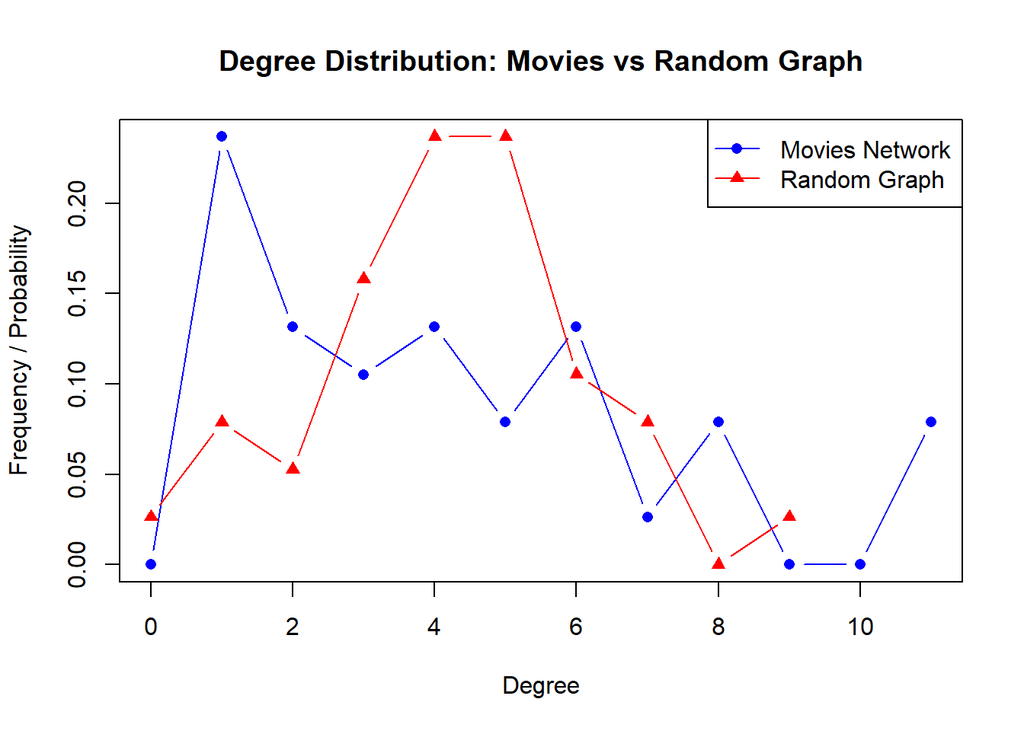

```r
# Calculate empirical degree distribution
emp.deg.dist <- degree_distribution(g.movies.connected)

# Generate an illustrative random graph
n.v <- vcount(g.movies.connected)
n.e <- ecount(g.movies.connected)
g.random <- sample_gnm(n.v, n.e)

# Calculate random graph degree distribution
rand.deg.dist <- degree_distribution(g.random)

# Plot distributions
max.deg <- max(length(emp.deg.dist), length(rand.deg.dist)) - 1

plot(
  0:(length(emp.deg.dist) - 1),
  emp.deg.dist,
  type = "b",
  col = "blue",
  pch = 16,
  xlab = "Degree",
  ylab = "Frequency / Probability",
  main = "Degree Distribution: Movies vs Random Graph",
  xlim = c(0, max.deg)
)

points(
  0:(length(rand.deg.dist) - 1),
  rand.deg.dist,
  type = "b",
  col = "red",
  pch = 17
)

legend(
  "topright",
  legend = c("Movies Network", "Random Graph"),
  col = c("blue", "red"),
  pch = c(16, 17),
  lty = 1
)
```

```r
# Identify bridge movie: high betweenness but not top degree
top5.betw <- head(dt.g.movies[order(-betweenness)]$name, 5)
top10.degree <- head(dt.g.movies[order(-degree)]$name, 10)

# Find the anomaly
bridge.movie.list <- setdiff(top5.betw, top10.degree)

if(length(bridge.movie.list) > 0) {
  bridge.movie <- bridge.movie.list[1]
  bridge.betweenness <- dt.g.movies[name == bridge.movie, betweenness]

  print(paste("Bridge Movie:", bridge.movie))
  print(paste("Exact Betweenness:", round(bridge.betweenness, 4)))
} else {
  print("No movie in the top 5 betweenness is outside the top 10 degree.")
}
```

```
## [1] "Bridge Movie: Now You See Me (2013)"
## [1] "Exact Betweenness: 84.4286"
```

Comparing the degree distribution of our movies network with an illustrative Erdős-Rényi random graph reveals structural differences. While the random graph’s degree distribution is bell-shaped and concentrated around its mean, our network shows a more right-skewed distribution. This suggests a tendency toward a “hub” structure, which is common in the film industry due to major franchises, although this effect is certainly amplified by our specific bipartite projection of only the top 50 movies.

A notable movie in this network is Now You See Me (2013). It ranks in the top 5 by betweenness centrality but falls outside the top 10 by degree. Its exact betweenness is 84.4286. This movie serves as a significant bridge because it acts as the shortest path connecting distinct, otherwise isolated clusters (such as different actor circles or genres), despite having relatively few direct connections itself.